# Radiometric dating

August 30 2015

### Introruction

This narrative is adapted from material posted as online exercises by the [National Association of Geoscience Teachers](http://serc.carleton.edu/NAGTWorkshops/petrology/teaching_examples/calculating_rb-sr_isochrons.html) and supplements the material in Box 3.1 of Zimmer and Emlen (pp 57-59). The basic problem we want to adress is that illustrated in figure 3.5 (pg. 61) Below

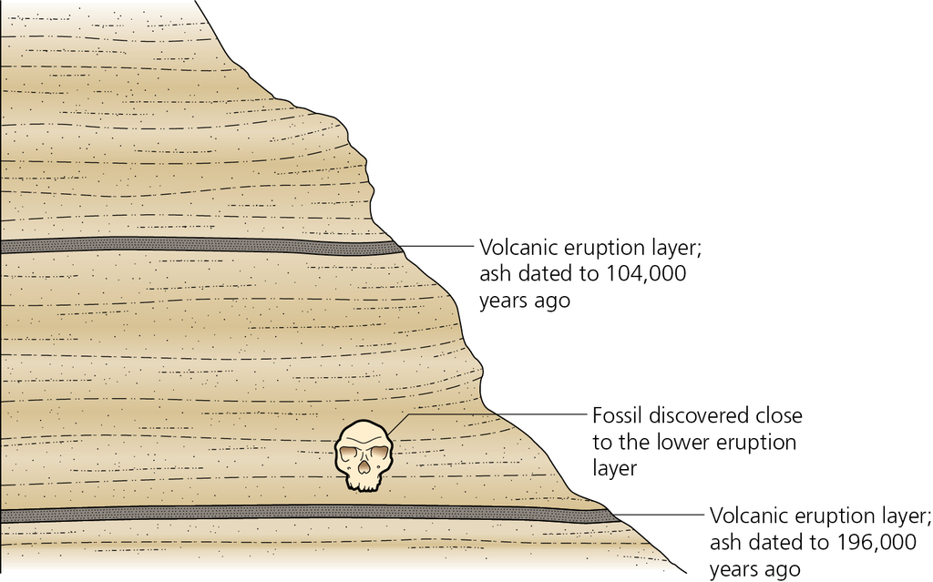

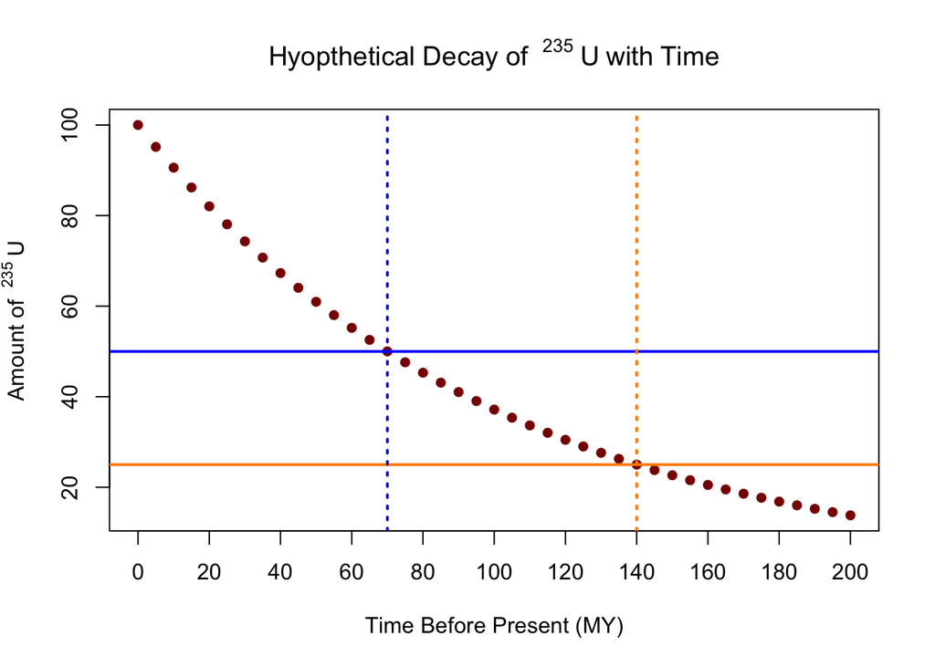

### The Basics of Isochrons

The basic approach for doing so is described in Box 3.1 of Zimmer and Emlen (pg. 57). The figure reproduced below is particularly important.

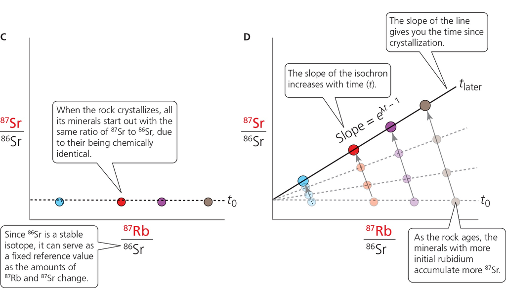

Look at the left panel first. It illustrates the following:

1. We have several samples of rocks from our site, all that crystallized at the same time.
2. At the time of formation, the material that crstallized all had the same ratio of <sup>87</sup>Sr, product of the radioactive decay of <sup>87</sup>RB^ and <sup>86</sup>Sr, both stable isotopes (although the total **amount** of Strontium varies from sample to sample). That is shown plotted on the Y axis. On the other hand, the different samples will have different amounts of <sup>87</sup>Rb, so the ratio of that element to <sup>86</sup>Sr will vary among samples (shown on the X axis above).

Now concentrate on the right panel. As time progresses, <sup>87</sup>Rb decays, so the amount of the daughter product of that decay, <sup>87</sup>Sr, increases, so the ratio of the two Sr isotope increases. Most importantly, **those samples that happened to have more Rb initially will produce more <sup>87</sup>Sr, resulting in a higher ratio of <sup>87</sup>Sr to <sup>86</sup>Sr (the amount of which remains constant over time).** Thus, at a given time (and we won’t work through the math, plotting the two ratios as shown results in a line, with a slope of e<sup>λt-1</sup>, where λ is the rate of decay per year, which in the case of <sup>87</sup>Rb has been determined to be 1.42 X 10<sup>-11</sup>. Thus, by determining the slope of the line and dividing its natural logarithm by λ, we can get an estimate of the age.

### An Example

But let’s look at some real data. These were obtained from four sites in California, three in the high Sierra (Yosemite region) and one from the coast range. The locations are shown in the Google Earth image below:

[figure not shown]

So the first thing we will do is to plot the isochrons for each of the four sites:

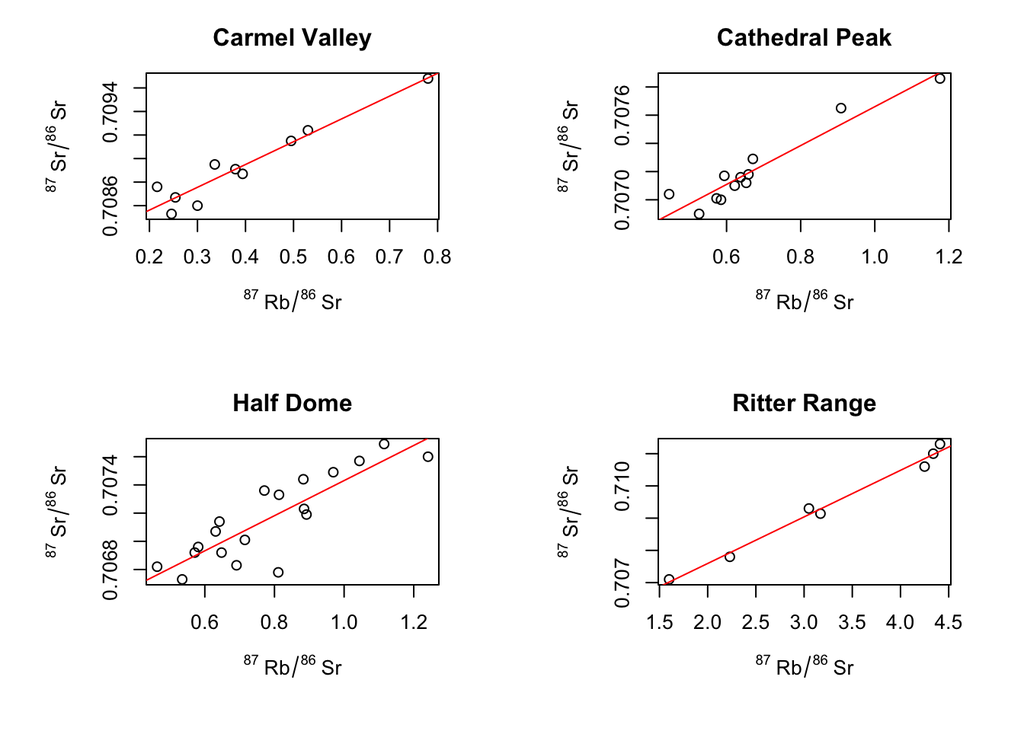

From these, we can not that the expected linear relationship is obtained in every case. Thus, we can move forward and determine the slopes, and from them the ages of the samples.

| Site | Slope | Age |
| --- | --- | --- |
| Carmel Valley | 0.0019368 | 136.0 |
| Cathedral Peak | 0.0013785 | 97.1 |
| Half Dome | 0.0012456 | 87.7 |
| Ritter Range | 0.0014457 | 102.0 |

### For you to think about

Based on what we have determined regarding the physical age of these particular geological strata, what would you be able to conclude about any fossils you found associated with them. In particular

1. What geological era(s) would you expect them to be associated with?
2. Assuming that the dates are determined within an accuracy of +/- 5 million years, how many distinct time points are represented in these four samples?

For a printable copy of this document, click **[here](https://dl.dropboxusercontent.com/u/9752688/BIO206/html/RadioCarbon1.html)**